# General(ized) Linear Models: Interactions

## Factorial designs and interactions

[figure not shown]

- Allow you to explore *interactions* (multiplicative effects)

If you have multiple categorical variables, you should *always* do factorial designs (unless you know why you aren’t).

## Interaction model

Add a new predictor (\(\beta_3\)) that is the product of \(X_1\) and \(X_2\):

\[Y = \beta_0 + \beta_1 X_1 + \beta_2 X_2 + \beta_3 (X_1 X_2) + \epsilon\]

The value of \(X_1\) varies with change in the value of \(X_2\) (and vice versa - these are not really separable).

## Factorial data

Biomass gain in plants fertilized with either added nitrogen or phosphorous.

[figure not shown]

## Factorial data

Biomass gain in plants fertilized with either added nitrogen or phosphorous.

```r
biomass <- read_csv("../data/biomass.csv")
str(biomass)
```

```
## spec_tbl_df[,6] [80 × 6] (S3: spec_tbl_df/tbl_df/tbl/data.frame)
##  $ nitrogen   : chr [1:80] "N+" "N+" "N+" "N+" ...
##  $ phosphorous: chr [1:80] "P+" "P+" "P+" "P+" ...
##  $ trt        : chr [1:80] "NP" "NP" "NP" "NP" ...
##  $ block      : num [1:80] 1 2 3 4 5 6 7 8 9 10 ...
##  $ plot       : num [1:80] 1 2 3 4 5 6 7 8 9 10 ...
##  $ biomass    : num [1:80] 23.1 34.4 25.6 32.6 27.7 ...
##  - attr(*, "spec")=
##   .. cols(
##   ..   nitrogen = col_character(),
##   ..   phosphorous = col_character(),
##   ..   trt = col_character(),
##   ..   block = col_double(),
##   ..   plot = col_double(),
##   ..   biomass = col_double()
##   .. )
```

## Factorial data

Balanced data: Equal *n* in each group

```r
biomass %>% group_by(nitrogen, phosphorous) %>% tally()
```

```
## # A tibble: 4 x 3
## # Groups:   nitrogen [2]
##   nitrogen phosphorous     n
##   <chr>    <chr>       <int>
## 1 N-       P-             20
## 2 N-       P+             20
## 3 N+       P-             20
## 4 N+       P+             20
```

Balanced data is the best to work with.

## Visualizing factorial data

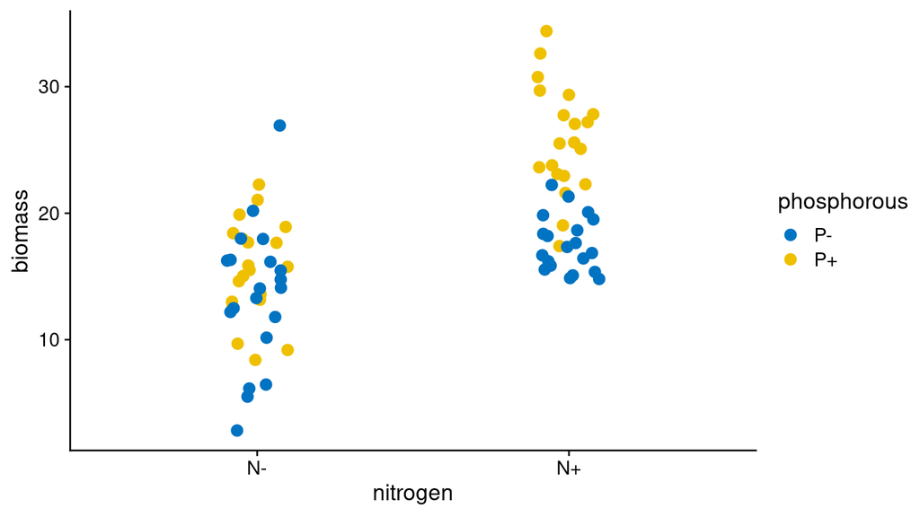

## Interaction plot

```r
ggplot(biomass, aes(x = nitrogen,
                    y = biomass,
                    color = phosphorous,
                    group = phosphorous)) +
  geom_point(position = position_jitter(width = 0.1), size = 3, pch = 1) +
  stat_summary(fun = mean, geom = "point", size = 6) +
  stat_summary(fun = mean, geom = "line", size = 1.5) +
  scale_color_paletteer_d("ggsci::default_jco")
```

## Interaction plot

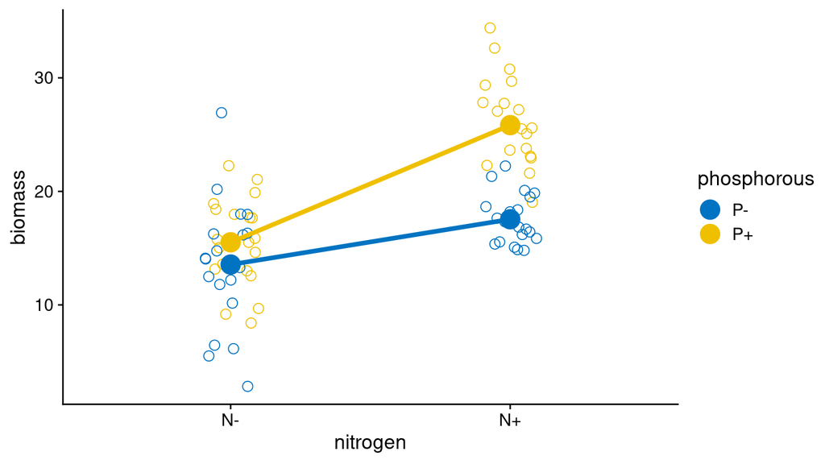

## Interaction plot

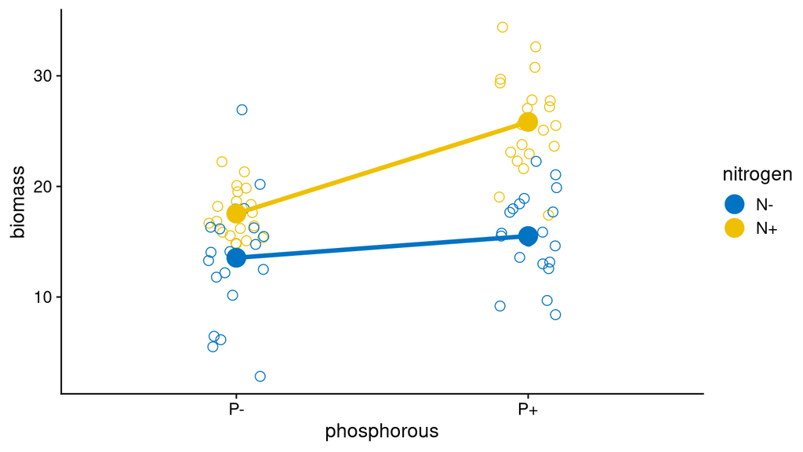

## Types of Interactions

[figure not shown]

## Group means

```r
biomass %>% group_by(nitrogen, phosphorous) %>%
  summarize(mean = mean(biomass),
            .groups = "drop")
```

```
## # A tibble: 4 x 3
##   nitrogen phosphorous  mean
##   <chr>    <chr>       <dbl>
## 1 N-       P-           13.6
## 2 N-       P+           15.5
## 3 N+       P-           17.5
## 4 N+       P+           25.8
```

## Two-way factorial ANOVA

```r
fm <- lm(biomass ~ nitrogen * phosphorous, data = biomass)
```

`nitrogen * phosphorous` expands to:

```r
fm <- lm(biomass ~ nitrogen + phosphorous + nitrogen:phosphorous,
         data = biomass)
```

`nitrogen:phosphorous` is the interaction term

## Two-way factorial ANOVA

```r
summary(fm)
```

```
##
## Call:
## lm(formula = biomass ~ nitrogen * phosphorous, data = biomass)
##
## Residuals:
##     Min      1Q  Median      3Q     Max
## -10.726  -2.241  -0.107   2.482  13.377
##
## Coefficients:
##                          Estimate Std. Error t value Pr(>|t|)
## (Intercept)               13.5526     0.9317  14.546  < 2e-16 ***
## nitrogenN+                 3.9901     1.3177   3.028  0.00336 **
## phosphorousP+              1.9610     1.3177   1.488  0.14083
## nitrogenN+:phosphorousP+   6.3280     1.8634   3.396  0.00109 **
## ---
## Signif. codes:  0 '***' 0.001 '**' 0.01 '*' 0.05 '.' 0.1 ' ' 1
##
## Residual standard error: 4.167 on 76 degrees of freedom
## Multiple R-squared:   0.57,  Adjusted R-squared:  0.553
## F-statistic: 33.58 on 3 and 76 DF,  p-value: 6.316e-14
```

## ANOVA table

If you have a significant interaction, the main effects not interpretable **without** clarification.

```r
fm <- lm(biomass ~ phosphorous * nitrogen, data = biomass)
anova(fm)
```

```
## Analysis of Variance Table
##
## Response: biomass
##                      Df  Sum Sq Mean Sq F value    Pr(>F)
## phosphorous           1  525.31  525.31  30.256 4.891e-07 ***
## nitrogen              1 1023.61 1023.61  58.957 4.535e-11 ***
## phosphorous:nitrogen  1  200.22  200.22  11.532  0.001091 **
## Residuals            76 1319.52   17.36
## ---
## Signif. codes:  0 '***' 0.001 '**' 0.01 '*' 0.05 '.' 0.1 ' ' 1
```

## Interpretations

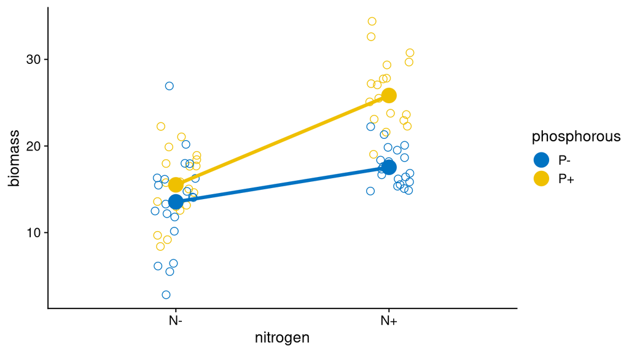

## Power to detect interactions is low (Wahlsten 1990)

For a 2 X 2 design

- Power to detect a main effect is 87%
- Power to detect the interaction is 16%

ANOVA will suggest additivity of effects when in fact they are multiplicative

## Under the hood

Numeric representations of `nitrogen` and `phosphorous`:

```r
biomass$n_num <- ifelse(biomass$nitrogen == "N-", 0, 1)
biomass$p_num <- ifelse(biomass$phosphorous == "P-", 0, 1)
```

Numeric representation of the interaction (multiple the other two numeric representations):

```r
biomass$interact <- biomass$n_num * biomass$p_num
```

1’s only for the “N+” & “P+” groups. 0’s for all others.

## 4 parameters define 4 groups

```r
biomass %>% slice(c(1,21,41,61,81))
```

```
## # A tibble: 4 x 9
##   nitrogen phosphorous trt   block  plot biomass n_num p_num interact
##   <chr>    <chr>       <chr> <dbl> <dbl>   <dbl> <dbl> <dbl>    <dbl>
## 1 N+       P+          NP        1     1    23.1     1     1        1
## 2 N+       P-          N         1    21    15.5     1     0        0
## 3 N-       P+          P         1    41    15.0     0     1        0
## 4 N-       P-          C         1    61    20.2     0     0        0
```

## Under the hood

```r
summary(lm(biomass ~ n_num + p_num + interact, data = biomass))
```

```
##
## Call:
## lm(formula = biomass ~ n_num + p_num + interact, data = biomass)
##
## Residuals:
##     Min      1Q  Median      3Q     Max
## -10.726  -2.241  -0.107   2.482  13.377
##
## Coefficients:
##             Estimate Std. Error t value Pr(>|t|)
## (Intercept)  13.5526     0.9317  14.546  < 2e-16 ***
## n_num         3.9901     1.3177   3.028  0.00336 **
## p_num         1.9610     1.3177   1.488  0.14083
## interact      6.3280     1.8634   3.396  0.00109 **
## ---
## Signif. codes:  0 '***' 0.001 '**' 0.01 '*' 0.05 '.' 0.1 ' ' 1
##
## Residual standard error: 4.167 on 76 degrees of freedom
## Multiple R-squared:   0.57,  Adjusted R-squared:  0.553
## F-statistic: 33.58 on 3 and 76 DF,  p-value: 6.316e-14
```

## Model matrix

R does the factor \(\rightarrow\) numeric conversion behind the scenes:

```r
mm <- model.matrix(biomass ~ nitrogen * phosphorous, data = biomass)
mm[15:25,]
```

```
##    (Intercept) nitrogenN+ phosphorousP+ nitrogenN+:phosphorousP+
## 15           1          1             1                        1
## 16           1          1             1                        1
## 17           1          1             1                        1
## 18           1          1             1                        1
## 19           1          1             1                        1
## 20           1          1             1                        1
## 21           1          1             0                        0
## 22           1          1             0                        0
## 23           1          1             0                        0
## 24           1          1             0                        0
## 25           1          1             0                        0
```

## Into the abyss…

ANOVA tables, sums of squares, and hypothesis tests.

- As soon as there are interactions with an unbalanced design, variables can share variance.

Questions get complicated:

1. What is the effect of variable 1 on y, ignoring variable 2?
2. What is the effect of variable 2 on y, ignoring variable 1?
3. What is the effect of variable 1 on y, controlling for variable 2?
4. What is the effect of variable 2 on y, controlling for variable 1?

## Partitioning variance

Different ways to partition variance has a cascading effect:

- Determines sums of squares, which
- Determines mean squares, which
- Determines *P* values

Thus you should be aware of how your ANOVA table is calculated.

## Types of sums of squares

**Type I**: “sequential,” “unweighted,” ordering of factors in the model matters, the R default, probably **not** what you want *if you have unbalanced sample sizes*

**Type II**: main effects allowed to overlap with their interaction terms, useful if interaction is weak

**Type III**: “weighted,” each reported effect controls for all the others (including interactions)

## Types of sums of squares

Each type tests subtly different hypotheses.

- Use Type I if you have balanced data
- Type I == Type III if the groups are balanced (ideal situation - you don’t have to choose)
- Type III matches the output of `summary(lm())` (so that’s nice)

## Unbalanced groups

Randomly drop 20 rows:

```r
set.seed(15)
biomass_ub <- biomass %>% slice(sample(1:nrow(.), nrow(.) - 20))
biomass_ub %>% group_by(nitrogen, phosphorous) %>% tally()
```

```
## # A tibble: 4 x 3
## # Groups:   nitrogen [2]
##   nitrogen phosphorous     n
##   <chr>    <chr>       <int>
## 1 N-       P-             17
## 2 N-       P+             11
## 3 N+       P-             16
## 4 N+       P+             16
```

## ANOVA Model 1

```r
fm1 <- lm(biomass ~ nitrogen * phosphorous, data = biomass_ub)
anova(fm1)
```

```
## Analysis of Variance Table
##
## Response: biomass
##                      Df  Sum Sq Mean Sq F value    Pr(>F)
## nitrogen              1  638.92  638.92 35.1276 1.999e-07 ***
## phosphorous           1  349.36  349.36 19.2076 5.207e-05 ***
## nitrogen:phosphorous  1  167.03  167.03  9.1832  0.003693 **
## Residuals            56 1018.55   18.19
## ---
## Signif. codes:  0 '***' 0.001 '**' 0.01 '*' 0.05 '.' 0.1 ' ' 1
```

## ANOVA Model 2

```r
fm2 <- lm(biomass ~ phosphorous * nitrogen, data = biomass_ub)
anova(fm2)
```

```
## Analysis of Variance Table
##
## Response: biomass
##                      Df  Sum Sq Mean Sq F value    Pr(>F)
## phosphorous           1  453.63  453.63 24.9408 6.118e-06 ***
## nitrogen              1  534.64  534.64 29.3944 1.299e-06 ***
## phosphorous:nitrogen  1  167.03  167.03  9.1832  0.003693 **
## Residuals            56 1018.55   18.19
## ---
## Signif. codes:  0 '***' 0.001 '**' 0.01 '*' 0.05 '.' 0.1 ' ' 1
```

## Type III sums of squares

```r
library(car)
Anova(fm1, type = "III")
```

```
## Anova Table (Type III tests)
##
## Response: biomass
##                      Sum Sq Df  F value    Pr(>F)
## (Intercept)          3444.6  1 189.3814 < 2.2e-16 ***
## nitrogen               75.5  1   4.1518  0.046326 *
## phosphorous             9.4  1   0.5170  0.475105
## nitrogen:phosphorous  167.0  1   9.1832  0.003693 **
## Residuals            1018.6 56
## ---
## Signif. codes:  0 '***' 0.001 '**' 0.01 '*' 0.05 '.' 0.1 ' ' 1
```

## Type III sums of squares

```r
library(car)
Anova(fm2, type = "III")
```

```
## Anova Table (Type III tests)
##
## Response: biomass
##                      Sum Sq Df  F value    Pr(>F)
## (Intercept)          3444.6  1 189.3814 < 2.2e-16 ***
## phosphorous             9.4  1   0.5170  0.475105
## nitrogen               75.5  1   4.1518  0.046326 *
## phosphorous:nitrogen  167.0  1   9.1832  0.003693 **
## Residuals            1018.6 56
## ---
## Signif. codes:  0 '***' 0.001 '**' 0.01 '*' 0.05 '.' 0.1 ' ' 1
```

## Key points

1. Check your sample sizes within groups
2. Pay attention when you have interaction terms
3. Think about your sums of squares
4. Type II or Type III is likely what you want

## Higher order interaction terms

It is difficult enough to interpret an interaction in a 2 X 2 ANOVA model.

- Higher order terms multiply and become impossible to comprehend

\[Biomass = \beta_0 + ... + \beta_k (N \times P \times K)\]

- What does a significant Nitrogen X Phosphorus X Potassium interaction mean?

Split your data and carry out two analyses unless you really must.

## I really want to know more about these Type III sums of squares

Check the Canvas resources.

## These disagreements are all specific to sums of squares and variance component estimation.

Alternatives:

- Model Comparisons & Likelihood
- Bayesian Analyses

## References

Wahlsten, D. 1990. Insensitivity of the Analysis of Variance to Heredity-Environment Interaction. *Behav. Brain Sci.* 13:109–120.